# DIVISIÓN TRACHEOPHYTA, EN EL CONTEXTO DEL APORTE DE LA UNIVERSIDAD DE CÓRDOBA PARA EL DEPARTAMENTO

Ronaldo David Campo Romero

2025-03-14

### DISTRIBUCIÓN EN EL MUNDO

En el mundo se ha reportado un total de **488,229 especies** de plantas vasculares, donde su abundancia disminuye gradualmente al aproximarse a los polos (Tracheophyta in Döring, 2023).

### TRACHEOPHYTA EN COLOMBIA

En Colombia se tiene registros oficiales (bases de datos GBIF Y SIB Colombia) de 34,721 especies pertenecientes a ocho clases conocidas (Tracheophyta in Döring, 2023).

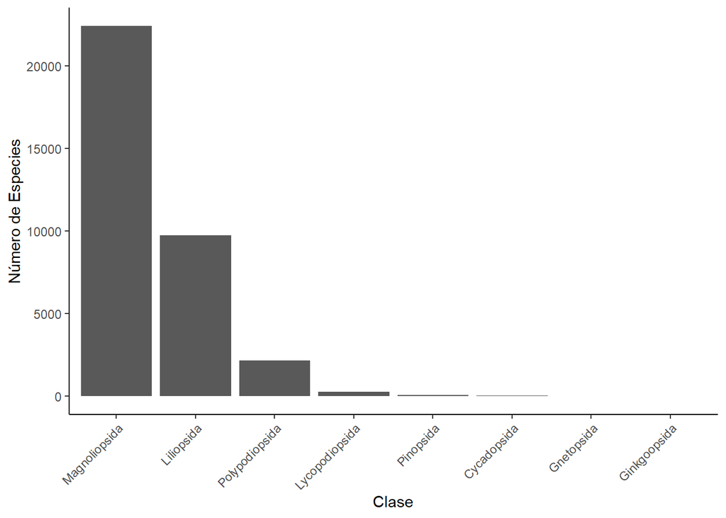

### TRACHEOPHYTA EN CÓRDOBA Y EL APORTE DE LA UNIVERSIDAD DE CÓRDOBA

En córdoba hay reportadas **2,011 especies** de plantas vasculares, de las cuales **576 proviene del aporte de investigaciones en la Universidad de Córdoba**, siendo al menos 500 especies tipicas del bosque seco tropical (Vega, 2023; Tracheophyta in Döring, 2023).

### CONCLUSIÓN

Debido a las consultas realizadas en las base de datos provenientes de diferentes investigaciones, se concluye que **la universidad de Córdoba genera un aporte del 28.64%** al conocimiento taxonómico de plantas vasculares en el departamento de Córdoba, en su mayoria especimenes pertenecientes al ecosistema de bosque seco tropical.

### REFERENCIAS

Ruiz Vega, R. (2023). Flora relictual del bosque seco tropical (bst) del departamento de Córdoba. Fondo Editorial - Universidad de Córdoba.

Tracheophyta in Döring M (2023). GBIF Backbone Patch. GBIF Secretariat. Checklist dataset https://doi.org/10.15468/l07d61 accessed via GBIF.org on 2025-03-14.